# ppdai_data_analyst

Kipmin

2019年3月13日

========================================================

```
## [1] "LC_COLLATE=Chinese (Simplified)_China.936;LC_CTYPE=Chinese (Simplified)_China.936;LC_MONETARY=Chinese (Simplified)_China.936;LC_NUMERIC=C;LC_TIME=Chinese (Simplified)_China.936"
```

将RStudio语言设置为中文，导入本文需要的库

在导入数据时，将所有类别更正，把各类认证都改为分类变量，是否首标，性别，初始评级，借款期限也都是分类变量，借款日期是日期变量。在导入时无法正常显示中文，把编码改为*GB2312*，空值是NULL字符串，标注出来用na（R的空值）代替。

```
## [1] 328553     21
```

```
## Classes 'spec_tbl_df', 'tbl_df', 'tbl' and 'data.frame': 328553 obs. of  21 variables:
##  $ ListingId       : num  126541 133291 142421 149711 152141 ...
##  $ 借款金额        : num  18000 9453 27000 25000 20000 ...
##  $ 借款期限        : Factor w/ 18 levels "12","24","6",..: 1 1 2 1 3 1 3 1 1 3 ...
##  $ 借款利率        : num  18 20 20 18 16 14 18 18 16 18 ...
##  $ 借款成功日期    : Date, format: NA NA ...
##  $ 初始评级        : Factor w/ 6 levels "A","B","C","D",..: 3 4 5 3 3 1 5 2 2 3 ...
##  $ 借款类型        : Factor w/ 4 levels "其他","普通",..: 1 1 2 1 3 2 3 2 1 3 ...
##  $ 是否首标        : Factor w/ 2 levels "否","是": 1 1 1 1 1 1 1 1 1 1 ...
##  $ 年龄            : num  35 34 41 34 24 36 27 32 33 25 ...
##  $ 性别            : Factor w/ 2 levels "男","女": 1 1 1 1 1 1 2 1 2 1 ...
##  $ 手机认证        : Factor w/ 2 levels "成功认证","未成功认证": 1 2 1 1 1 1 1 1 1 1 ...
##  $ 户口认证        : Factor w/ 2 levels "未成功认证","成功认证": 1 2 1 2 2 2 2 2 1 2 ...
##  $ 视频认证        : Factor w/ 2 levels "成功认证","未成功认证": 1 2 2 1 1 1 1 1 1 1 ...
##  $ 学历认证        : Factor w/ 2 levels "未成功认证","成功认证": 1 1 1 1 1 1 1 1 1 1 ...
##  $ 征信认证        : Factor w/ 2 levels "未成功认证","成功认证": 1 1 1 1 1 1 1 1 1 1 ...
##  $ 淘宝认证        : Factor w/ 2 levels "未成功认证","成功认证": 1 1 1 1 1 1 1 1 1 1 ...
##  $ 历史成功借款次数: int  11 4 5 6 13 7 15 7 7 9 ...
##  $ 历史成功借款金额: num  40326 14500 21894 36190 77945 ...
##  $ 总待还本金      : num  8713 7891 11726 9703 0 ...
##  $ 历史正常还款期数: int  57 13 25 41 118 56 75 52 41 49 ...
##  $ 历史逾期还款期数: int  16 1 3 1 14 0 8 0 2 4 ...
##  - attr(*, "problems")=Classes 'tbl_df', 'tbl' and 'data.frame': 328553 obs. of  5 variables:
##   ..$ row     : int  1 2 3 4 5 6 7 8 9 10 ...
##   ..$ col     : chr  "借款成功日期" "借款成功日期" "借款成功日期" "借款成功日期" ...
##   ..$ expected: chr  "date like %Y/%m/%d" "date like %Y/%m/%d" "date like %Y/%m/%d" "date like %Y/%m/%d" ...
##   ..$ actual  : chr  "2015-05-04" "2015-03-16" "2016-04-26" "2015-03-30" ...
##   ..$ file    : chr  "'LC.csv'" "'LC.csv'" "'LC.csv'" "'LC.csv'" ...
##  - attr(*, "spec")=
##   .. cols(
##   ..   ListingId = col_double(),
##   ..   借款金额 = col_double(),
##   ..   借款期限 = col_factor(levels = NULL, ordered = FALSE, include_na = FALSE),
##   ..   借款利率 = col_double(),
##   ..   借款成功日期 = col_date(format = "%Y/%m/%d"),
##   ..   初始评级 = col_factor(levels = c("A", "B", "C", "D", "E", "F"), ordered = FALSE, include_na = FALSE),
##   ..   借款类型 = col_factor(levels = NULL, ordered = FALSE, include_na = FALSE),
##   ..   是否首标 = col_factor(levels = NULL, ordered = FALSE, include_na = FALSE),
##   ..   年龄 = col_double(),
##   ..   性别 = col_factor(levels = NULL, ordered = FALSE, include_na = FALSE),
##   ..   手机认证 = col_factor(levels = NULL, ordered = FALSE, include_na = FALSE),
##   ..   户口认证 = col_factor(levels = NULL, ordered = FALSE, include_na = FALSE),
##   ..   视频认证 = col_factor(levels = NULL, ordered = FALSE, include_na = FALSE),
##   ..   学历认证 = col_factor(levels = NULL, ordered = FALSE, include_na = FALSE),
##   ..   征信认证 = col_factor(levels = NULL, ordered = FALSE, include_na = FALSE),
##   ..   淘宝认证 = col_factor(levels = NULL, ordered = FALSE, include_na = FALSE),
##   ..   历史成功借款次数 = col_integer(),
##   ..   历史成功借款金额 = col_double(),
##   ..   总待还本金 = col_double(),
##   ..   历史正常还款期数 = col_integer(),
##   ..   历史逾期还款期数 = col_integer()
##   .. )
```

```
##    ListingId           借款金额         借款期限         借款利率
##  Min.   :  126541   Min.   :   100   12     :215330   Min.   : 6.5
##  1st Qu.:11908871   1st Qu.:  2033   6      : 84486   1st Qu.:20.0
##  Median :19523251   Median :  3397   9      : 10769   Median :20.0
##  Mean   :19079479   Mean   :  4424   10     :  5472   Mean   :20.6
##  3rd Qu.:26298621   3rd Qu.:  5230   11     :  5351   3rd Qu.:22.0
##  Max.   :32819531   Max.   :500000   3      :  1993   Max.   :24.0
##                                      (Other):  5152
##   借款成功日期    初始评级      借款类型      是否首标         年龄
##  Min.   :NA       A: 10284   其他   : 97302   否:241090   Min.   :17.00
##  1st Qu.:NA       B: 33188   普通   :118103   是: 87463   1st Qu.:24.00
##  Median :NA       C:131705   电商   :  1069               Median :28.00
##  Mean   :NA       D:134860   APP闪电:112079               Mean   :29.14
##  3rd Qu.:NA       E: 17027                                3rd Qu.:33.00
##  Max.   :NA       F:  1489                                Max.   :56.00
##  NA's   :328553
##  性别              手机认证            户口认证            视频认证
##  男:221946   成功认证  :123007   未成功认证:318448   成功认证  : 18501
##  女:106607   未成功认证:205546   成功认证  : 10105   未成功认证:310052
##
##
##
##
##
##        学历认证            征信认证            淘宝认证
##  未成功认证:214429   未成功认证:318947   未成功认证:327401
##  成功认证  :114124   成功认证  :  9606   成功认证  :  1152
##
##
##
##
##
##  历史成功借款次数  历史成功借款金额    总待还本金      历史正常还款期数
##  Min.   :  0.000   Min.   :      0   Min.   :      0   Min.   :   0.000
##  1st Qu.:  0.000   1st Qu.:      0   1st Qu.:      0   1st Qu.:   0.000
##  Median :  2.000   Median :   5000   Median :   2542   Median :   5.000
##  Mean   :  2.323   Mean   :   8786   Mean   :   3722   Mean   :   9.948
##  3rd Qu.:  3.000   3rd Qu.:  10355   3rd Qu.:   5447   3rd Qu.:  13.000
##  Max.   :649.000   Max.   :7405926   Max.   :1172653   Max.   :2507.000
##
##  历史逾期还款期数
##  Min.   : 0.0000
##  1st Qu.: 0.0000
##  Median : 0.0000
##  Mean   : 0.4233
##  3rd Qu.: 0.0000
##  Max.   :60.0000
##
```

可以看出通过手机认证的最多，其次学历……最少的淘宝认证。历史成功借款次数，历史成功借款金额，总待还本金，历史正常还款期数，历史逾期还款期数，借款金额等看上去都有异常值出现。

# 整理数据

通过认证的方式， 根据认证难易程度，赋给每种认证不同的权重，我的想法是，**通过越多认证的人，相比于通过少的人借贷会更有优势。** **我认为手机认证是最容易通过的认证，淘宝认证是最难通过的认证，难易程度的考究是通过各个认证通过的百分比体现的。**

# 单变量绘图选择

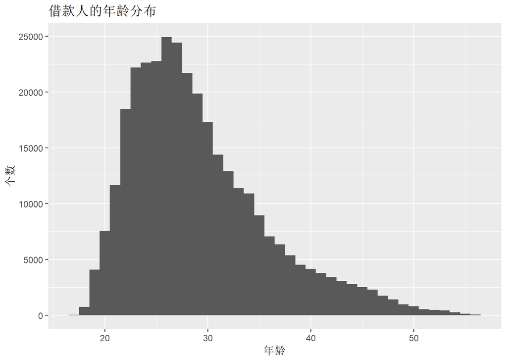

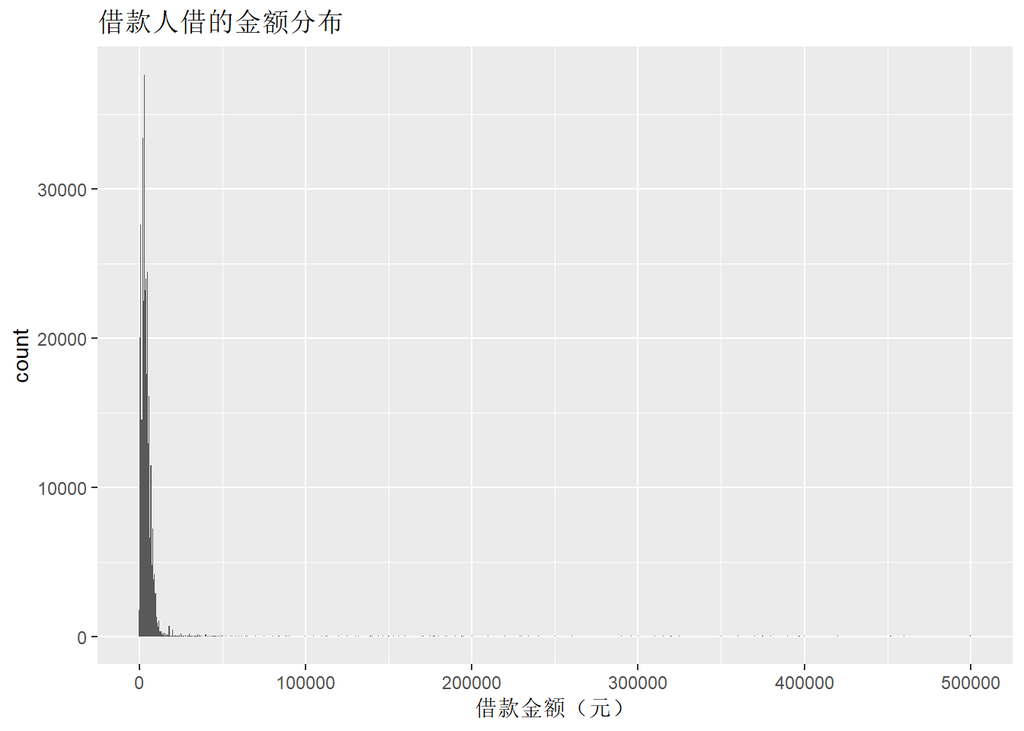

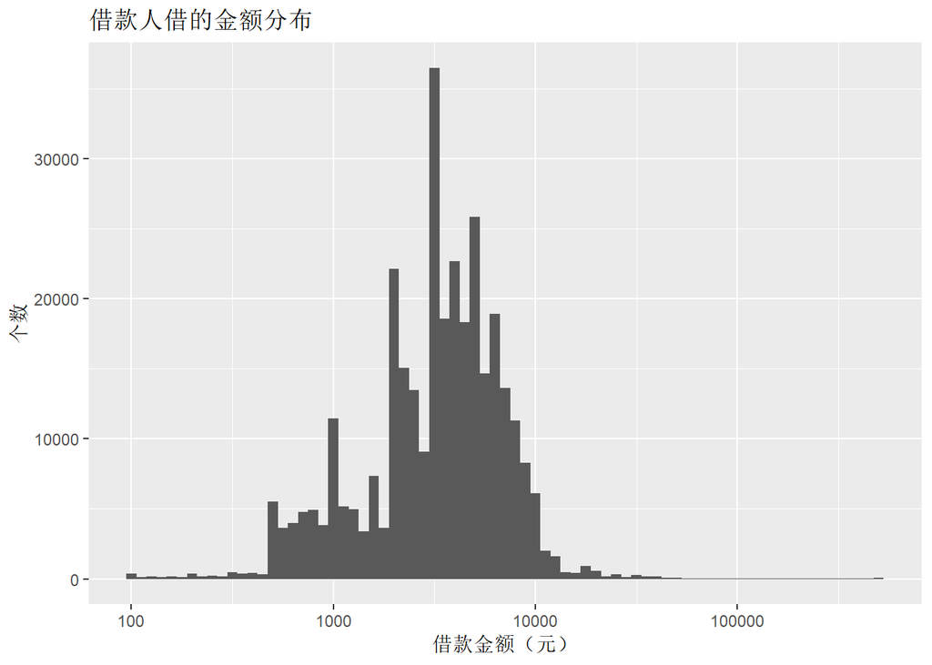

可以看到大多数人借的钱都在万元以内。

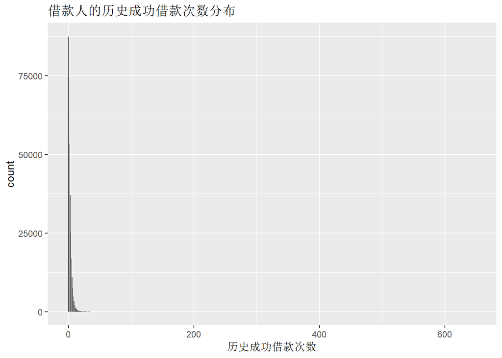

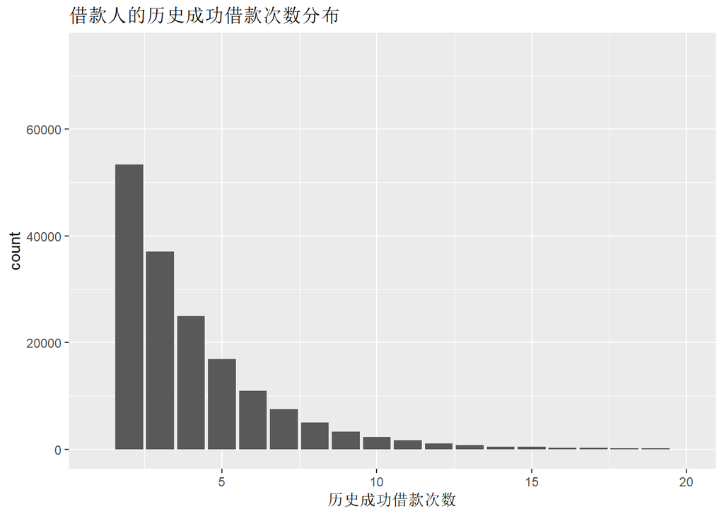

历史成功借款次数的人数也是次数越多，人数越少。

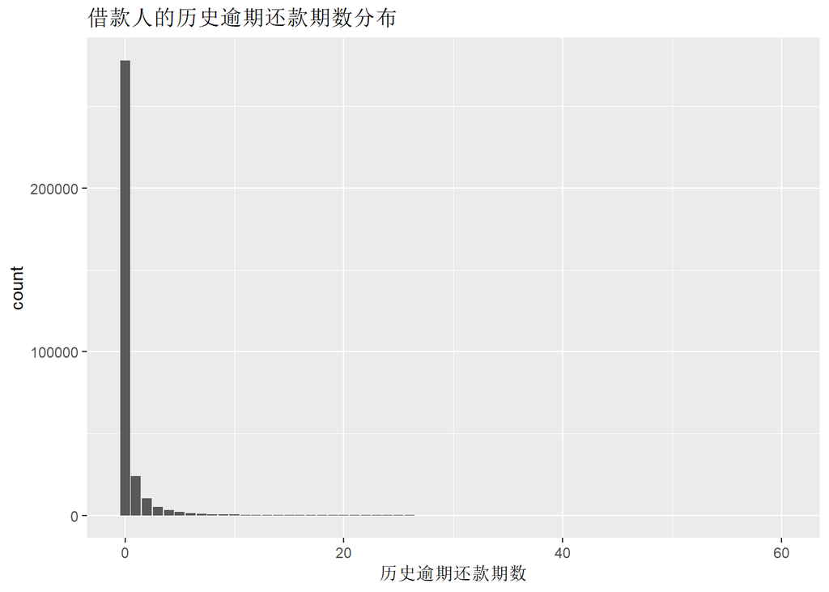

去掉0逾期的人数，与后面的长尾异常数据

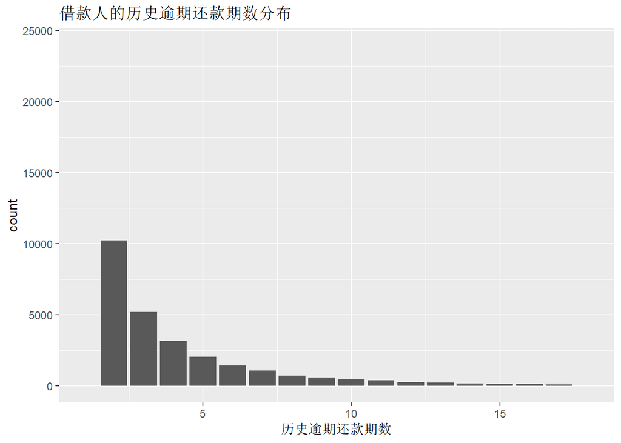

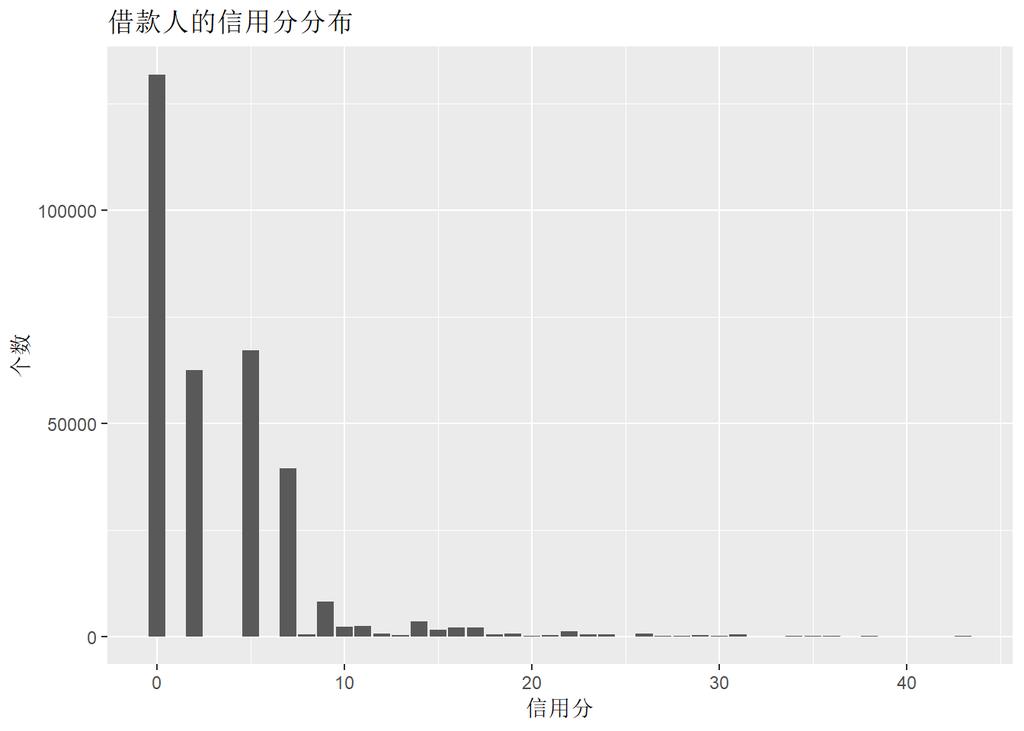

可以看到有10万人都没有通过任何一项认证，通过认证越多的用户越少，是符合正常规律的。

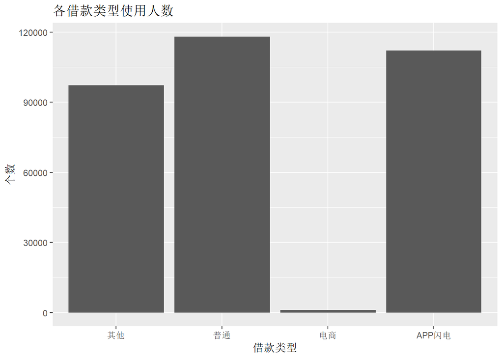

电商渠道要远远低于其他3个渠道的人数。

# 单变量分析

### 你的数据集结构是什么？

包括一个主键（listingid）、7个标的特征和13个成交当时的借款人信息

| ListingId | 列表序号，为列表的唯一键。 |
| --- | --- |
| 借款金额 | 列表成交总金额。 |
| 借款期限 | 总的期数（按月计）。 |
| 借款利率 | 年化利率（百分数）。 |
| 借款成功日期 | 列表成交的日期。都在2015年1月1日以后。 |
| 初始评级 | 列表成交时的信用评级。AAA为安全标，AA为赔标，A-F为信用等级。 |
| 借款类型 | 分为’应收安全标’，‘电商’，‘APP闪电’，‘普通’和‘其他’。 |
| 是否首标 | 该标是否为借款人首标。 |
| 年龄 | 借款人在该列表借款成功时的年龄。 |
| 性别 | 该列表借款人性别。 |
| 手机认证 | 该列表借款人手机实名认证是否成功。 |
| 户口认证 | 该列表借款人户口认证是否成功。 |
| 视频认证 | 该列表借款人视频认证是否成功。 |
| 学历认证 | 该列表借款人学历认证是否成功。成功则表示有大专及以上学历。 |
| 征信认证 | 该列表借款人征信认证是否成功。成功则表示有人行征信报告。 |
| 淘宝认证 | 该列表借款人淘宝认证是否成功。成功则表示为淘宝店主。 |
| 历史成功借款次数 | 借款人在该列表成交之前的借款成功次数。 |
| 历史成功借款金额 | 借款人在该列表成交之前的借款成功金额。 |
| 总待还本金 | 借款人在该列表成交之前待还本金金额。 |
| 历史正常还款期数 | 借款人在该列表成交之前的按期还款期数。 |
| 历史逾期还款期数 | 借款人在该列表成交之前的逾期还款期数。 |
| credit_score | 通过各项维度认证综合而来的分数 |

### 你的数据集内感兴趣的主要特性有哪些？

历史逾期还款期数，借款金额，借款类型，信用分，年龄，历史成功借款次数 如何通过这些特征更好地筛选借款人，降低逾期还款率，减少坏账

### 你认为数据集内哪些其他特征可以帮助你探索兴趣特点？

6个认证特征可以帮助我更加精确的确认借款人的信用如何

### 根据数据集内已有变量，你是否创建了任何新变量？

通过6个认证的难度各不相同，**按认证的难度不同，给认证模式不同的权重**，再加起来得到一个新的信用分数(credit_score)变量

### 在已经探究的特性中，是否存在任何异常分布？你是否对数据进行一些操作，如清洁、调整或改变数据的形式？如果是，你为什么会这样做？

在借款利率和借款金额上，人数分布差异太大，借款金额上，金额差距过大，credit_score的人数分布上差异太大，对差异过大的变量取了对数，使图像看上去更加清晰。暂时没有发现异常分布

# 双变量绘图选择

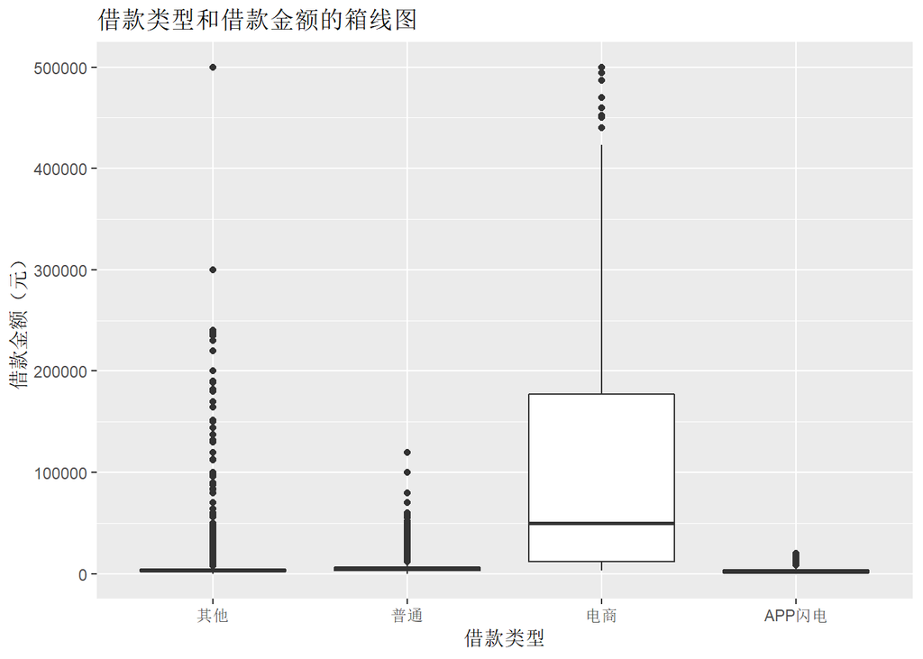

除了电商渠道外，其他三个的box几乎看不见，用summary方法查看下其余三个的中位数等。

```
## LC$借款类型: 其他
##    Min. 1st Qu.  Median    Mean 3rd Qu.    Max.
##     100    2519    3329    4119    4720  500000
## --------------------------------------------------------
## LC$借款类型: 普通
##    Min. 1st Qu.  Median    Mean 3rd Qu.    Max.
##     100    3000    4679    5245    6500  120000
## --------------------------------------------------------
## LC$借款类型: 电商
##    Min. 1st Qu.  Median    Mean 3rd Qu.    Max.
##    3000   12000   50000  115368  177000  500000
## --------------------------------------------------------
## LC$借款类型: APP闪电
##    Min. 1st Qu.  Median    Mean 3rd Qu.    Max.
##     100     934    1940    2765    4000   20000
```

电商渠道最低只能借3000元，比其他三个要多很多，说明拍拍贷认为电商渠道借钱的人都有很高的偿还能力。

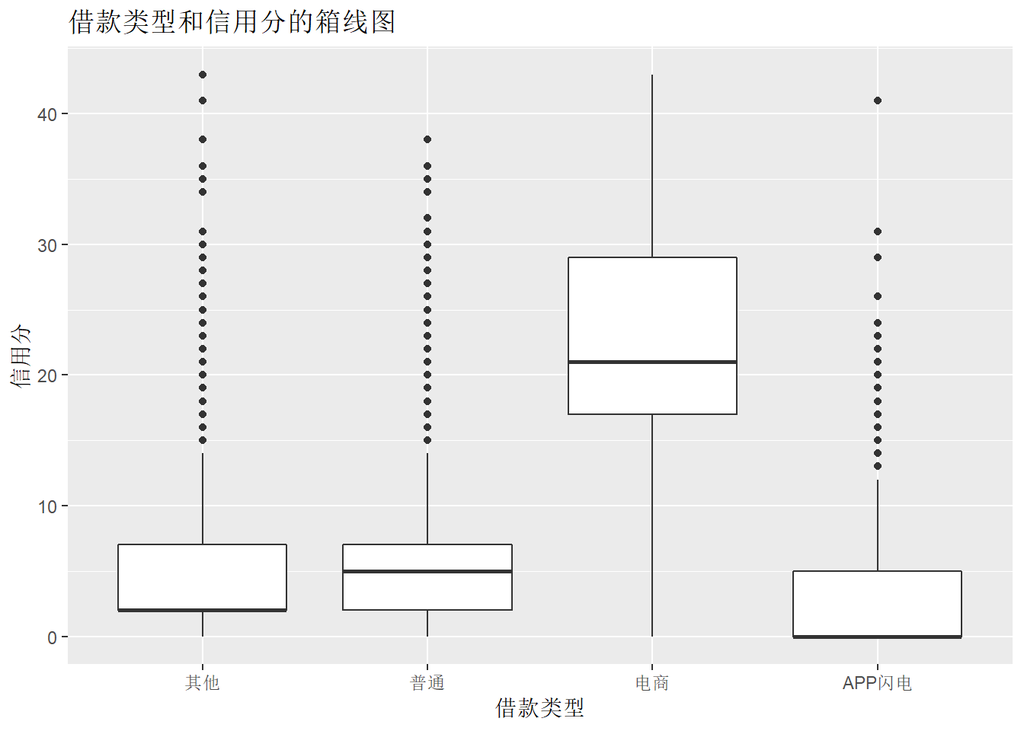

对电商渠道的用户要求的认证也很高，也证明了上方电商渠道能借到更多钱的一个原因。 对app闪电的用户要求是最低的，一半以上的人都是0认证。

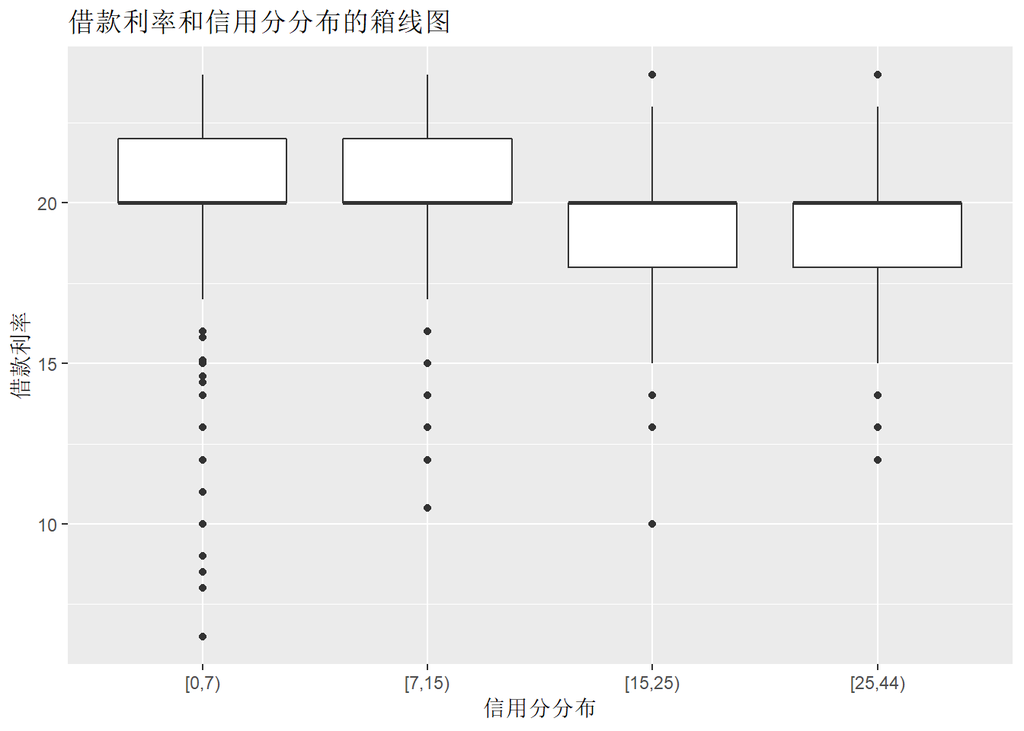

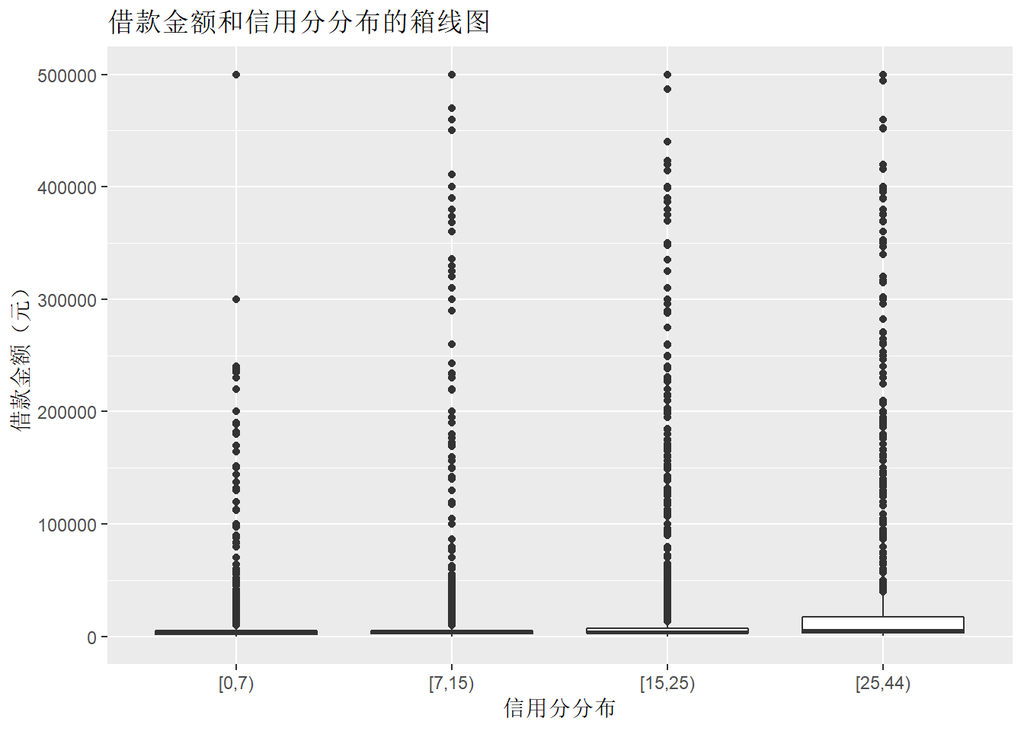

通过信用分最高的一部分用户分布来看，信用分越高的用户似乎能借到更多的钱，用summary方法查看详细的值。

```
## LC$credit_score.bucket: [0,7)
##    Min. 1st Qu.  Median    Mean 3rd Qu.    Max.
##     100    2000    3296    3893    5080  500000
## --------------------------------------------------------
## LC$credit_score.bucket: [7,15)
##    Min. 1st Qu.  Median    Mean 3rd Qu.    Max.
##     100    2500    3600    4990    5500  500000
## --------------------------------------------------------
## LC$credit_score.bucket: [15,25)
##    Min. 1st Qu.  Median    Mean 3rd Qu.    Max.
##     100    2944    4000   10122    6958  500000
## --------------------------------------------------------
## LC$credit_score.bucket: [25,44)
##    Min. 1st Qu.  Median    Mean 3rd Qu.    Max.
##     135    3200    5000   40082   17670  500000
```

通过平均数可以看出，信用分越高的用户借到的钱的确更多。

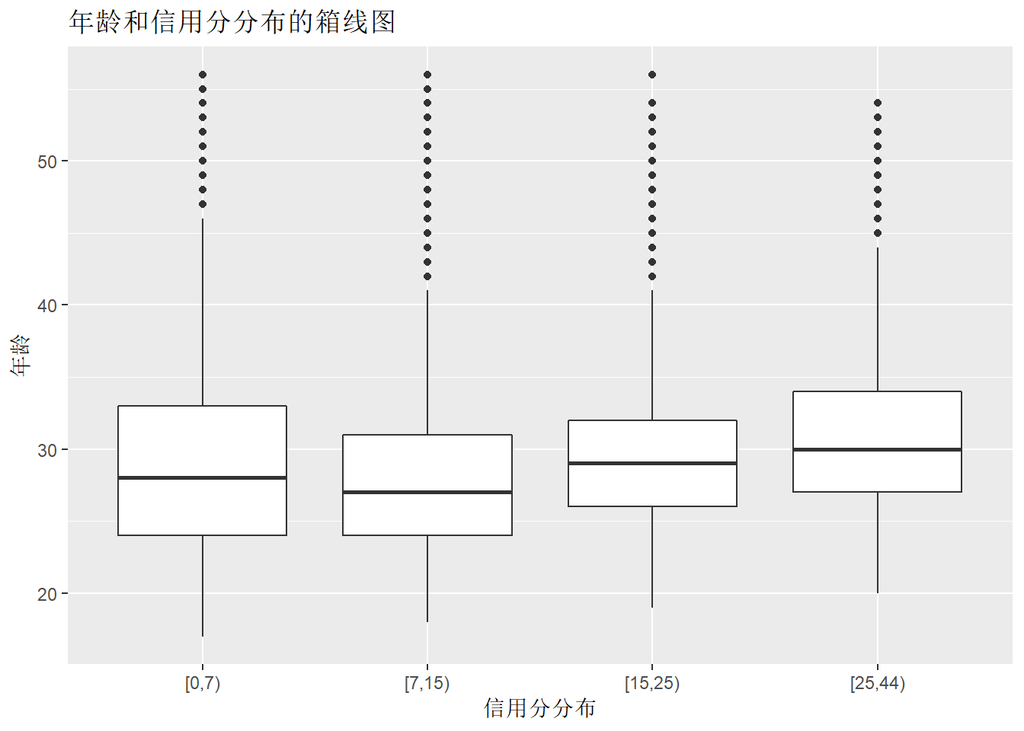

信用分越高的人有更高的年龄，绝大多数人处在20-35这个年龄区间。7-15这个区间年龄偏低，应该有很多大学生群体拉低了整体。

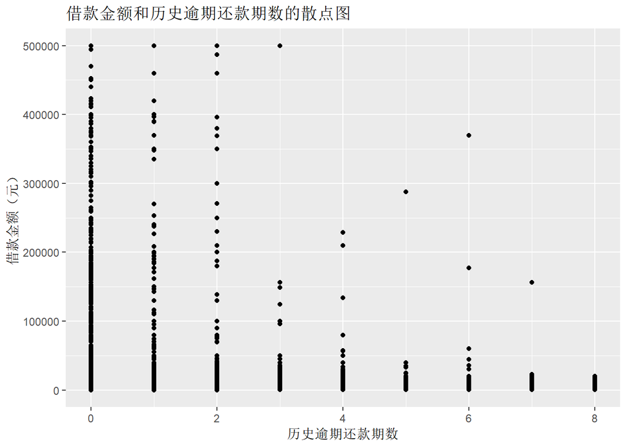

通过此图可以看到，逾期多的人借款金额高的人有变少，不排除逾期期数少的情况。

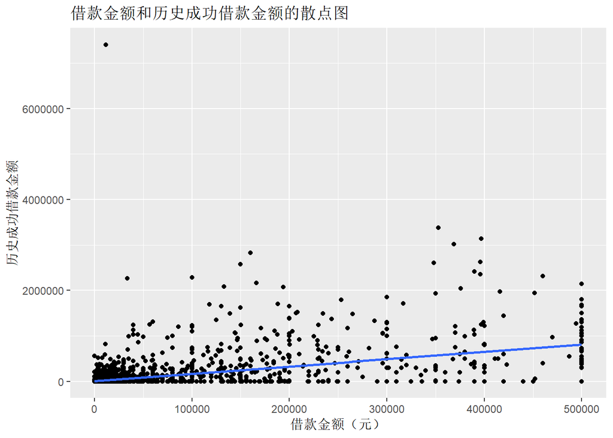

左上角有一个异常值，除去它后再重新绘图

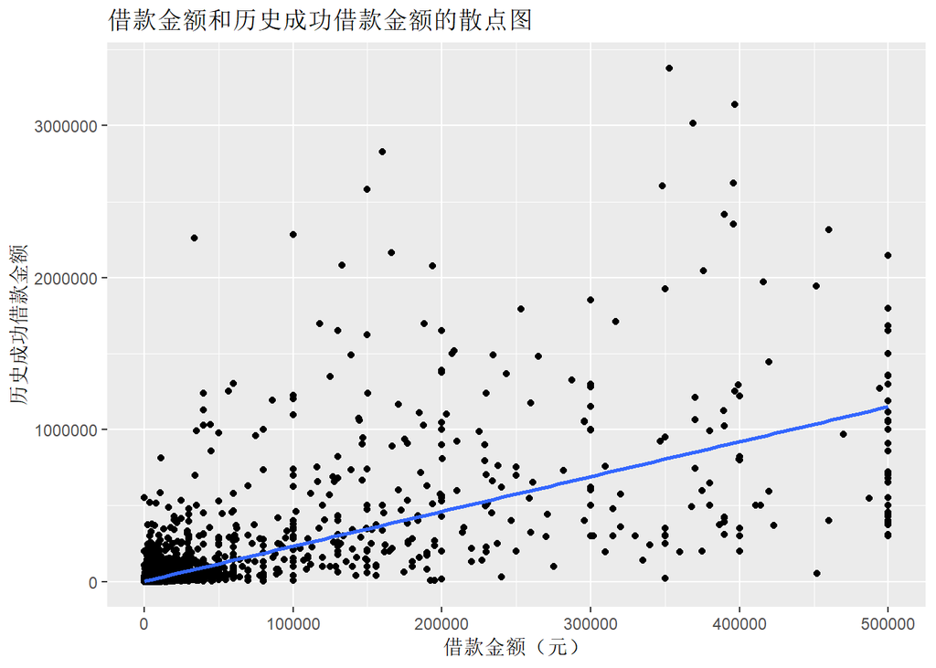

```
##
##  Pearson's product-moment correlation
##
## data:  借款金额 and 历史成功借款金额
## t = 454.66, df = 241090, p-value < 0.00000000000000022
## alternative hypothesis: true correlation is not equal to 0
## 95 percent confidence interval:
##  0.6772770 0.6815751
## sample estimates:
##       cor
## 0.6794319
```

历史成功借款金额和借款金额相关性达到了0.67，证明拍拍贷会把历史成功借款金额看作一个重要的指标。

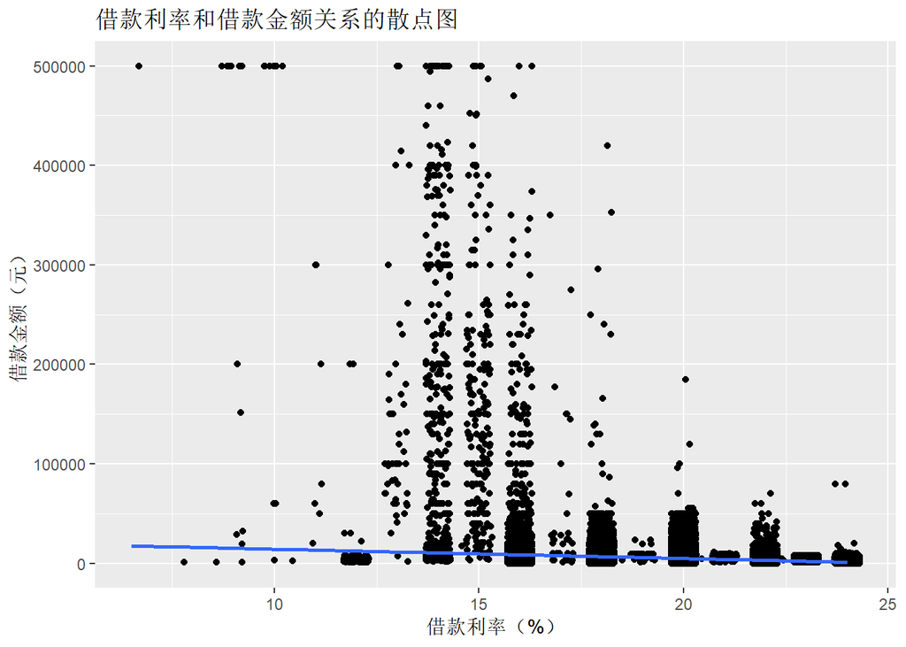

```
##
##  Pearson's product-moment correlation
##
## data:  LC$借款利率 and LC$借款金额
## t = -85.92, df = 328550, p-value < 0.00000000000000022
## alternative hypothesis: true correlation is not equal to 0
## 95 percent confidence interval:
##  -0.1515827 -0.1448942
## sample estimates:
##        cor
## -0.1482401
```

借款金额大多都低于5万，借款金额很多的利率大多都分布在15%左右，没有相关性。

# 双变量分析

### 探讨你在这部分探究中观察到的一些关系。这些感兴趣的特性与数据集内其他特性有什么区别？

借电商渠道的人数很少，与其他渠道相比是借款金额很高，信用分也很高。

### 你是否观察到主要特性与其他特性之间的有趣关系？

在我的观察中，我新建的变量信用分（credit_score）与其他借款相关的变量几乎都有相关性。

### 你发现最强的关系是什么？

是借款金额和历史成功借款金额的关系，除去不相关的和异常值，相关性达到了0.67

### 异常现象

0认证的人能借到的钱出乎我的意料，为何拍拍贷会把钱借给这些任何身份都没有认证的人？

# 多变量绘图选择

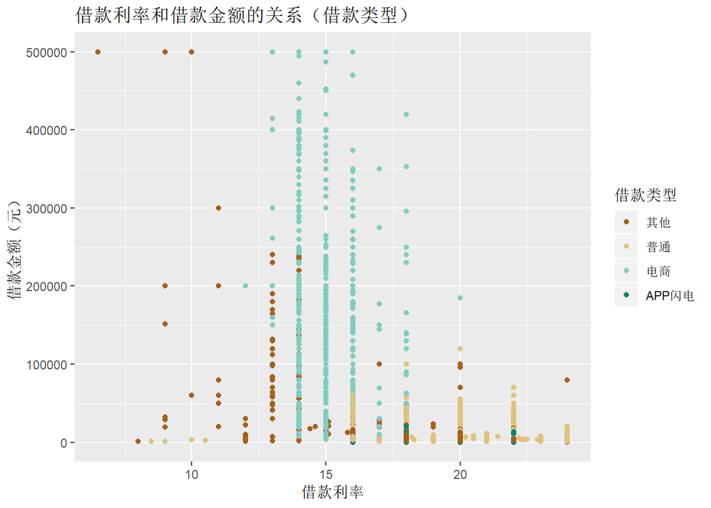

此公司在不同的借款类型给的借款利率是不同的，电商类型贡献了最多的高额中等利率贷款，其他类型的大多数借款有更低的利率，而普通和app闪电都是高息低额贷款。

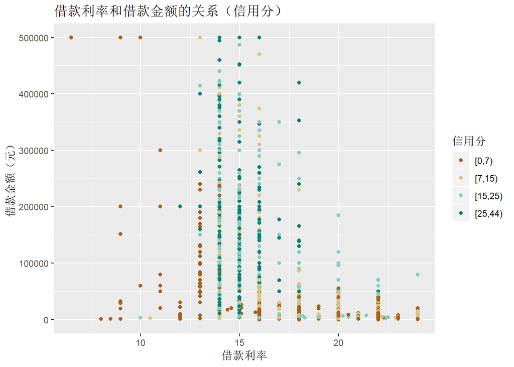

认证的越多，即信用分越高的人，相比于信用分低的人，有更大的概率借到利率在13-16的贷款，信用分低的人更多的处在16-24利率之间，也可以印证信用分高的都是电商类型用户。

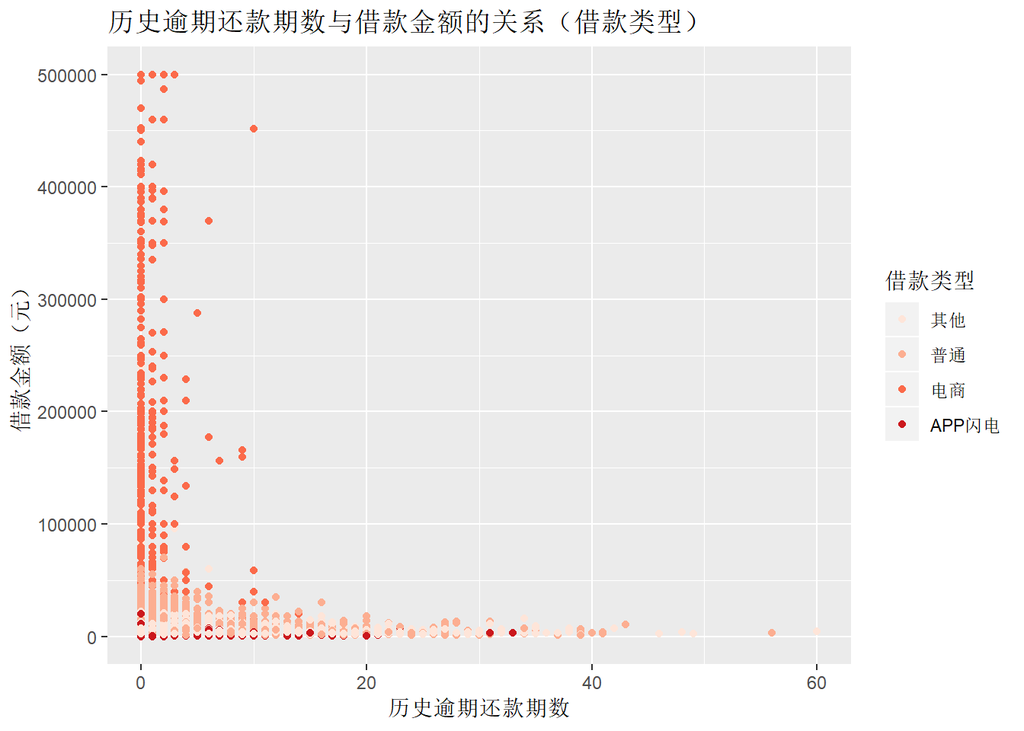

有少数异常数据，筛选掉异常数据。

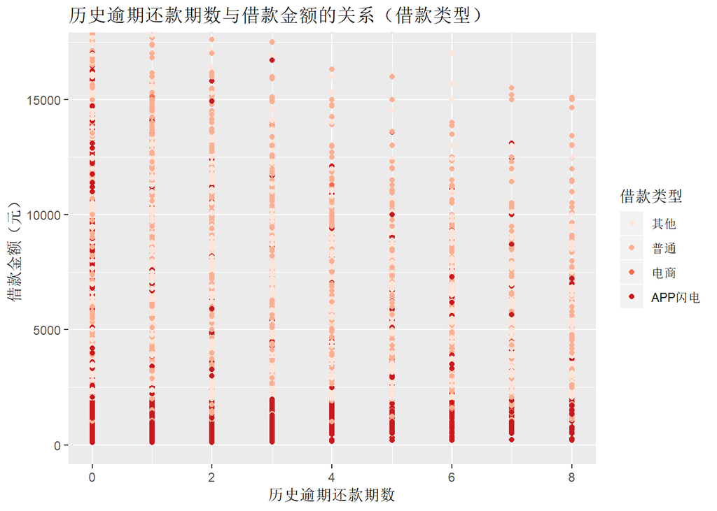

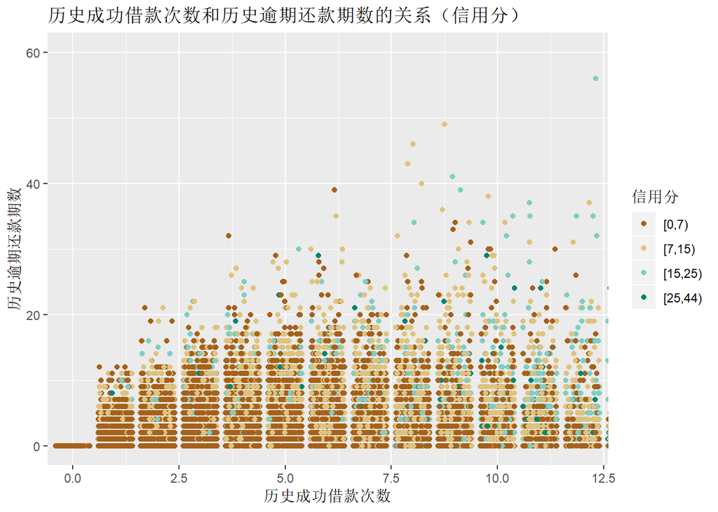

高信用分的人有更高的借贷次数，在借贷次数中高信用分的占比也增大了，但是高信用分的人相对于低信用分的人有更高的违约次数。

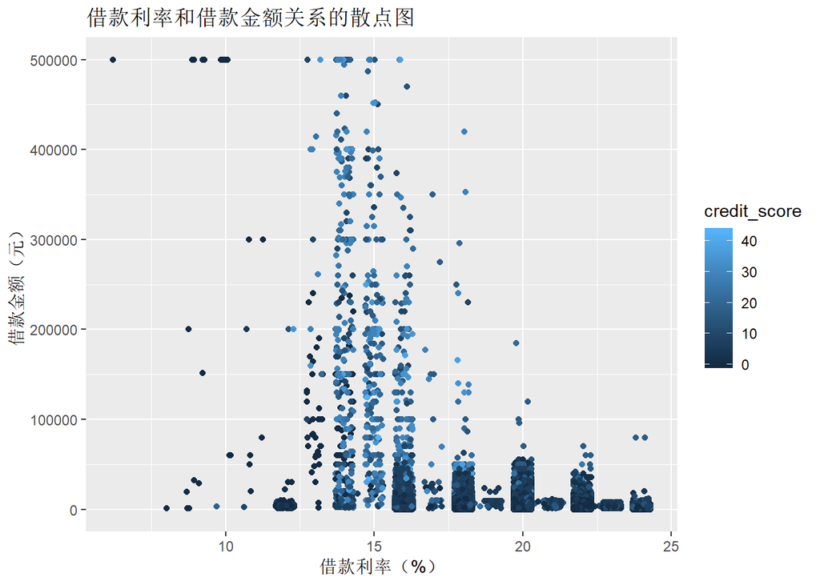

# 多变量分析

### 探讨你在这部分探究中观察到的一些关系。通过观察感兴趣的特性，是否存在相互促进的特性？

历史逾期还款期数越高的人，有着更高的信用分，即，认证了更多项，在探索中，逾期次数过高的人的确借贷的次数变少了，借贷金额也相对变低。

### 这些特性之间是否存在有趣或惊人的联系呢？

借款类型是最影响借款利率和借款金额的分类，相比之下，信用分会影响借款的金额和利率，历史成功借款金额和历史逾期还款期数也对借款金额有很大相关性。

### 选项：你是否创建过数据集的任何模型？讨论你模型的优缺点。

```
##
## Calls:
## p3: lm(formula = I(借款金额) ~ 手机认证 + 学历认证 + 视频认证 + 户口认证 +
##     征信认证 + 淘宝认证 + I(历史成功借款金额) + 借款类型, data = subset(LC,
##     借款类型 != "其他"))
## p4: lm(formula = I(借款金额) ~ 手机认证 + 学历认证 + 视频认证 + 户口认证 +
##     征信认证 + 淘宝认证 + I(历史成功借款金额) + 借款类型 + 历史正常还款期数,
##     data = subset(LC, 借款类型 != "其他"))
## p5: lm(formula = I(借款金额) ~ 手机认证 + 学历认证 + 视频认证 + 户口认证 +
##     征信认证 + 淘宝认证 + I(历史成功借款金额) + 借款类型 + 历史正常还款期数 +
##     历史成功借款次数, data = subset(LC, 借款类型 != "其他"))
##
## ======================================================================================================
##                                           p3                     p4                     p5
## ------------------------------------------------------------------------------------------------------
##   (Intercept)                              3252.390***            4878.879***            5313.338***
##                                             (85.379)               (85.933)               (85.083)
##   手机认证: 未成功认证                      233.557***            -537.562***            -761.421***
##                                             (51.470)               (51.354)               (50.816)
##   学历认证: 成功认证/未成功认证             770.510***             671.038***             781.548***
##                                             (40.797)               (40.134)               (39.673)
##   视频认证: 未成功认证                      922.393***             498.925***             480.438***
##                                             (87.771)               (86.444)               (85.394)
##   户口认证: 成功认证/未成功认证           -2853.371***            -872.970***            -735.263***
##                                            (125.839)              (125.740)              (124.225)
##   征信认证: 成功认证/未成功认证             683.850***            1395.079***            1741.693***
##                                            (138.884)              (136.809)              (135.225)
##   淘宝认证: 成功认证/未成功认证           -4745.789***           -5767.068***           -6663.423***
##                                            (366.504)              (360.594)              (356.409)
##   I(历史成功借款金额)                         0.109***               0.127***               0.136***
##                                              (0.001)                (0.001)                (0.001)
##   借款类型: 电商/普通                     88590.114***           83510.271***           81581.448***
##                                            (361.711)              (360.267)              (356.801)
##   借款类型: APP闪电/普通                  -2320.976***           -1796.505***           -1161.283***
##                                             (46.340)               (45.951)               (46.162)
##   历史正常还款期数                                                -132.205***              83.903***
##                                                                     (1.489)                (3.212)
##   历史成功借款次数                                                                      -1209.086***
##                                                                                           (15.979)
## ------------------------------------------------------------------------------------------------------
##   R-squared                                   0.475                  0.492                  0.505
##   adj. R-squared                              0.475                  0.492                  0.505
##   sigma                                    9064.638               8913.921               8805.599
##   F                                       23249.841              22427.115              21413.455
##   p                                           0.000                  0.000                  0.000
##   Log-likelihood                       -2435316.558           -2431438.738           -2428610.862
##   Deviance                       19000531981193.648     18373863895699.246     17929941392602.664
##   AIC                                   4870655.116            4862901.475            4857247.724
##   BIC                                   4870768.980            4863025.690            4857382.290
##   N                                      231251                 231251                 231251
## ======================================================================================================
```

创建了一个关于借贷金额的模型

优点：我判断其他类型的借贷是由专人去寻找贷款人的，所以不计入模型,提高了模型的精度。

缺点：我创建的模型相关性只达到了0.5。。

# 定稿图与总结

### 绘图一

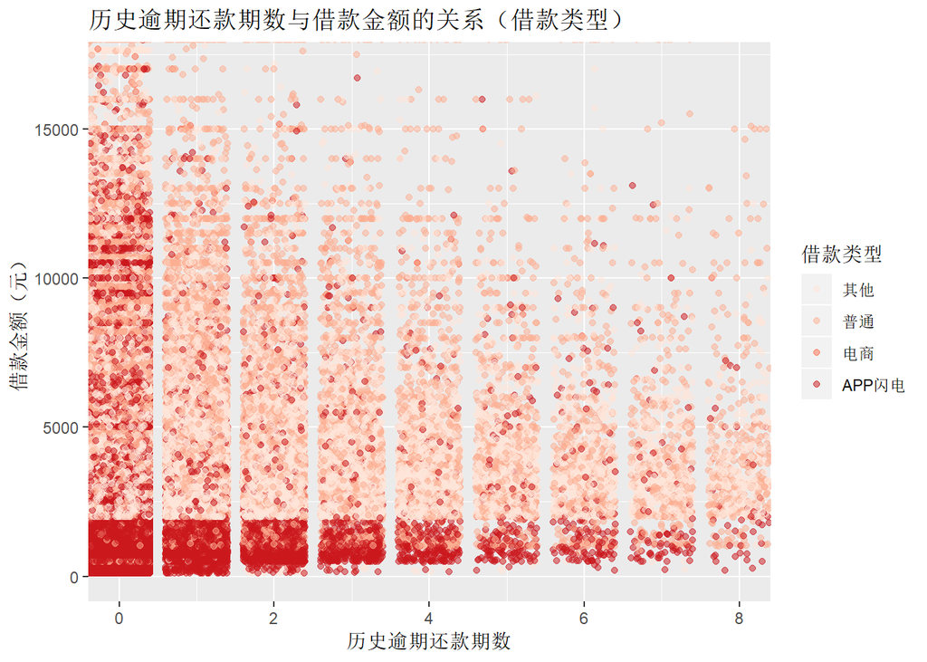

### 描述一

可以看出拍拍贷公司在自己的app中借贷额度普遍不高，逾期还款率较其他类型来说也少很多，逾期还款期数越高的人，借贷的人数也越来越低。

### 绘图二

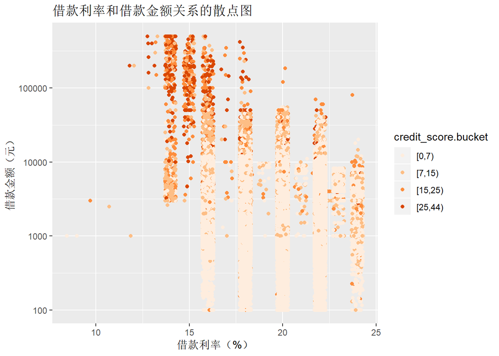

### 描述二

信用分高的人都处在中间利率，借款金额高的区域，低信用分的用户都在图中右下角区域，图中除去了其他类型的数据，这部分是人为判断的，所以从信用分无法体现出来。

### 绘图三

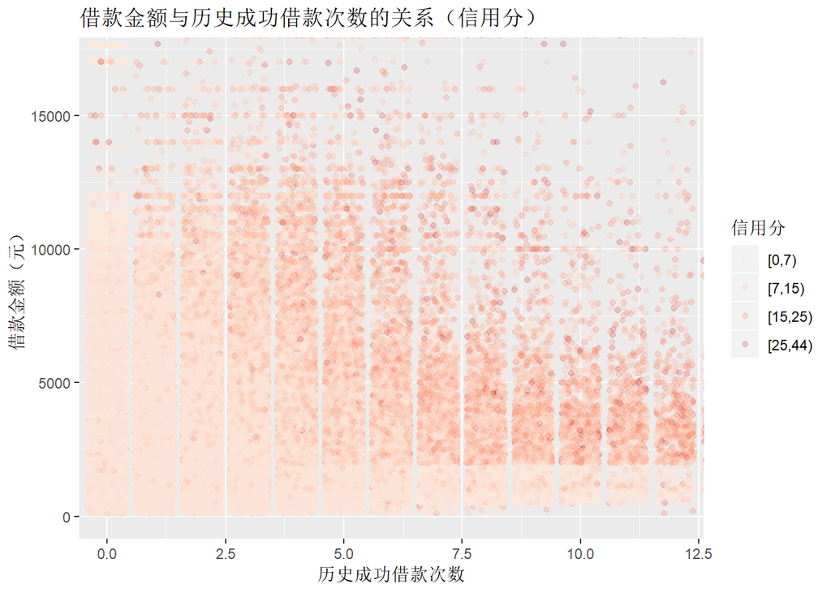

### 描述三

大多数信用分高的人都有更高的借款金额和更多的借款次数，拍拍贷对信用高的用户更加信任，同时，成功借款次数更多的用户中，借款金额高的用户占比也在提高。

# 反思

拍拍贷的数据分析项目包含了15年到16年的部分业务数据，那时也是P2P金融最火的一段时间，由于数据量过大，我只集中精力研究了LC表，我先了解了LC表中的各个变量，再从我感兴趣的方面下手，**作为一个借贷公司，没有银行的背书，如何把钱借给能还钱的人？**，我先对借贷的人群进行了初步了解，然后假设了一个信用分的模型，从此下手探索我的模型与借款人行为的关系，发现借贷行为与信用分都产生了相关性。在更深入的了解借贷行为时，发现人们的行为与我的想象有很大出入，我认为人们会更非常在乎自己的信用是否良好，但仅仅是借贷公司而不是国家银行的话，人们似乎都不在意是否逾期与拖欠，我便开始了解拍拍贷公司如何解决这一问题，它的做法是，大额低息借贷都是经过借贷人员考察的借贷人，人为检查借贷人的资产偿还能力，这是**借贷类型中的其他**。电商渠道可以借高额贷款是因为与某些电商合作，借贷人的违约成本较高，而且利率不低，平衡好风险的情况下是可以做的，而自己的软件只做一些给大学生提供的小额贷款，利率高，而且大学生相对来说违约的情况更少。但是通过后面的分析发现逾期的情况还是很多，如何进一步缩小逾期的可能？我猜测借贷人的历史行为也会成为拍拍贷衡量是否放贷的标准之一，分析后也验证了我的猜测。